# BCR + GEX Integration Tutorial – Part 2: Seurat Analysis and Annotation

## 7.11 DEG heatmap: top 5 markers per cluster

The heatmap runs `FindAllMarkers()` and plots the top 5 upregulated genes per cluster as a z-scored average expression heatmap. This gives an unbiased initial view of what distinguishes each cluster and provides hints that the pairwise DEG analysis in the following sections will confirm or refine.

For faster computation, install the `presto` package – Seurat will use it automatically:

```r
install.packages("devtools")
devtools::install_github("immunogenomics/presto")
```

```r
all_markers <- FindAllMarkers(
  obj, only.pos = TRUE, min.pct = 0.25,
  logfc.threshold = 0.25, verbose = FALSE
)
```

[output not shown]

```r
top5 <- all_markers %>%
  dplyr::group_by(cluster) %>%
  dplyr::slice_max(order_by = avg_log2FC, n = 5) %>%
  dplyr::ungroup()

message("FindAllMarkers complete. Total DEGs: ", nrow(all_markers))
```

```
## FindAllMarkers complete. Total DEGs: 12261
```

```
## As of Seurat v5, we recommend using AggregateExpression to perform pseudo-bulk analysis.
```

```
## First group.by variable `seurat_clusters` starts with a number, appending `g` to ensure valid variable names
```

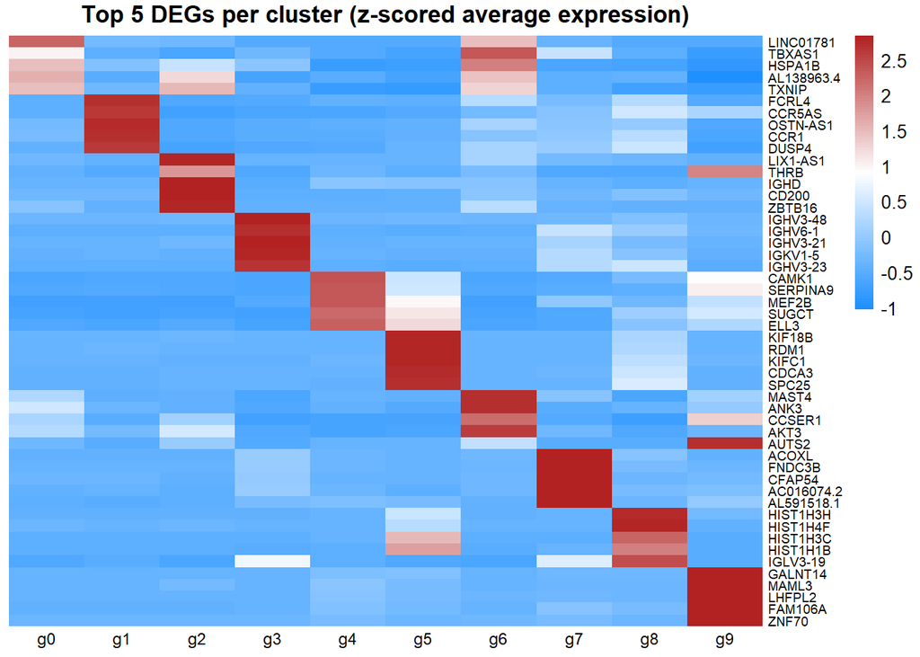

```r
if (nrow(top5) > 0) {
  genes_to_plot_hm <- unique(as.character(top5$gene))
  genes_to_plot_hm <- intersect(genes_to_plot_hm, rownames(obj))

  avg_expr <- AverageExpression(
    obj, features = genes_to_plot_hm, group.by = "seurat_clusters",
    assays = "RNA", layer = "data", verbose = FALSE
  )$RNA

  avg_scaled <- t(scale(t(avg_expr)))
  avg_scaled[!is.finite(avg_scaled)] <- 0
  rownames(avg_scaled) <- rownames(avg_expr)
  colnames(avg_scaled) <- colnames(avg_expr)

  gene_order_hm    <- unique(as.character(top5$gene)[as.character(top5$gene) %in% rownames(avg_scaled)])
  cluster_order_hm <- colnames(avg_scaled)[order(as.numeric(gsub("^g", "", colnames(avg_scaled))))]
  avg_scaled       <- avg_scaled[gene_order_hm, cluster_order_hm, drop = FALSE]

  pheatmap::pheatmap(
    avg_scaled, cluster_rows = FALSE, cluster_cols = FALSE,
    color        = colorRampPalette(c("dodgerblue", "white", "firebrick"))(100),
    fontsize_row = 7, fontsize_col = 9, angle_col = 0,
    main         = "Top 5 DEGs per cluster (z-scored average expression)",
    border_color = NA
  )
}
```

```r
deg_0_vs_1_6 <- FindMarkers(obj, ident.1 = 0, ident.2 = c(1, 6),
                             min.pct = 0.25, logfc.threshold = 0.1,
                             only.pos = FALSE, verbose = FALSE)
deg_1_vs_0_6 <- FindMarkers(obj, ident.1 = 1, ident.2 = c(0, 6),
                             min.pct = 0.25, logfc.threshold = 0.1,
                             only.pos = FALSE, verbose = FALSE)
deg_6_vs_0_1 <- FindMarkers(obj, ident.1 = 6, ident.2 = c(0, 1),
                             min.pct = 0.25, logfc.threshold = 0.1,
                             only.pos = FALSE, verbose = FALSE)
for (res in list(list(deg_0_vs_1_6, "Cluster 0 vs 1+6"),
                 list(deg_1_vs_0_6, "Cluster 1 vs 0+6"),
                 list(deg_6_vs_0_1, "Cluster 6 vs 0+1"))) {
  df      <- res[[1]]
  label   <- res[[2]]
  df$gene <- rownames(df)
  df      <- df %>% dplyr::arrange(desc(avg_log2FC))
  message("\nTop 30 higher in ", label, ":")
  print(knitr::kable(
    head(df[, c("gene", "avg_log2FC", "pct.1", "pct.2", "p_val_adj")], 30),
    digits = 4, caption = paste("Top 30 DEGs --", label)
  ))
}
```

```
##
## Top 30 higher in Cluster 0 vs 1+6:
```

```
##
##
## Table: Top 30 DEGs -- Cluster 0 vs 1+6
##
## |           |gene       | avg_log2FC| pct.1| pct.2| p_val_adj|
## |:----------|:----------|----------:|-----:|-----:|---------:|
## |LINC01781  |LINC01781  |     1.9841| 0.558| 0.197|         0|
## |MARCKSL1   |MARCKSL1   |     1.8945| 0.263| 0.112|         0|
## |VPREB3     |VPREB3     |     1.7329| 0.610| 0.254|         0|
## |SELENOM    |SELENOM    |     1.6715| 0.283| 0.135|         0|
## |AL138963.4 |AL138963.4 |     1.4569| 0.408| 0.256|         0|
## |TXNIP      |TXNIP      |     1.3376| 0.910| 0.694|         0|
## |P2RX5      |P2RX5      |     1.3007| 0.391| 0.182|         0|
## |DDIT4      |DDIT4      |     1.2409| 0.525| 0.367|         0|
## |EEF1B2     |EEF1B2     |     1.1198| 0.952| 0.915|         0|
## |PIK3IP1    |PIK3IP1    |     1.0610| 0.295| 0.180|         0|
## |RPL3       |RPL3       |     1.0495| 0.974| 0.959|         0|
## |AC119396.1 |AC119396.1 |     1.0303| 0.445| 0.225|         0|
## |HSPA1B     |HSPA1B     |     0.9646| 0.381| 0.287|         0|
## |LY86-AS1   |LY86-AS1   |     0.9400| 0.258| 0.141|         0|
## |MT-ND3     |MT-ND3     |     0.9201| 0.937| 0.914|         0|
## |TBXAS1     |TBXAS1     |     0.9181| 0.284| 0.168|         0|
## |SNHG7      |SNHG7      |     0.9171| 0.510| 0.454|         0|
## |IGHV5-78   |IGHV5-78   |     0.9053| 0.258| 0.200|         0|
## |RPS3A      |RPS3A      |     0.8971| 0.993| 0.961|         0|
## |HIST1H4C   |HIST1H4C   |     0.8888| 0.683| 0.620|         0|
## |RPS3       |RPS3       |     0.8887| 0.988| 0.960|         0|
## |MT-CYB     |MT-CYB     |     0.8849| 0.969| 0.943|         0|
## |RPS12      |RPS12      |     0.8838| 0.997| 0.967|         0|
## |RPS21      |RPS21      |     0.8785| 0.981| 0.964|         0|
## |MT-ATP6    |MT-ATP6    |     0.8743| 0.951| 0.946|         0|
## |NIBAN3     |NIBAN3     |     0.8728| 0.331| 0.172|         0|
## |GNG7       |GNG7       |     0.8577| 0.499| 0.351|         0|
## |RPS18      |RPS18      |     0.8570| 0.993| 0.969|         0|
## |SNHG6      |SNHG6      |     0.8547| 0.598| 0.532|         0|
## |RPL39      |RPL39      |     0.8516| 0.995| 0.961|         0|
```

```
##
## Top 30 higher in Cluster 1 vs 0+6:
```

```
##
##
## Table: Top 30 DEGs -- Cluster 1 vs 0+6
##
## |         |gene     | avg_log2FC| pct.1| pct.2| p_val_adj|
## |:--------|:--------|----------:|-----:|-----:|---------:|
## |DHRS9    |DHRS9    |     3.8208| 0.370| 0.011|         0|
## |FCRL4    |FCRL4    |     3.7142| 0.603| 0.035|         0|
## |ACY3     |ACY3     |     3.5971| 0.285| 0.029|         0|
## |CCR5AS   |CCR5AS   |     3.5810| 0.317| 0.016|         0|
## |USP18    |USP18    |     3.5593| 0.395| 0.025|         0|
## |CMTM3    |CMTM3    |     3.5022| 0.343| 0.016|         0|
## |PTMS     |PTMS     |     3.4910| 0.361| 0.013|         0|
## |MT2A     |MT2A     |     3.3462| 0.426| 0.046|         0|
## |RGS1     |RGS1     |     3.3048| 0.427| 0.046|         0|
## |DUSP4    |DUSP4    |     3.2556| 0.258| 0.014|         0|
## |OSTN-AS1 |OSTN-AS1 |     3.1789| 0.321| 0.023|         0|
## |ISG15    |ISG15    |     3.1159| 0.703| 0.159|         0|
## |IFIT1    |IFIT1    |     3.0778| 0.397| 0.053|         0|
## |CCR1     |CCR1     |     3.0572| 0.681| 0.079|         0|
## |CTSW     |CTSW     |     2.9971| 0.262| 0.017|         0|
## |IFIT3    |IFIT3    |     2.9061| 0.479| 0.076|         0|
## |RSAD2    |RSAD2    |     2.9012| 0.353| 0.047|         0|
## |SMCO4    |SMCO4    |     2.8862| 0.275| 0.024|         0|
## |HCK      |HCK      |     2.8263| 0.442| 0.034|         0|
## |DUSP2    |DUSP2    |     2.7611| 0.438| 0.104|         0|
## |GPR137B  |GPR137B  |     2.7399| 0.279| 0.022|         0|
## |IFI6     |IFI6     |     2.6879| 0.607| 0.147|         0|
## |GPR82    |GPR82    |     2.6783| 0.345| 0.030|         0|
## |ITGAX    |ITGAX    |     2.6756| 0.470| 0.039|         0|
## |CMPK2    |CMPK2    |     2.6711| 0.341| 0.045|         0|
## |WARS     |WARS     |     2.6597| 0.462| 0.073|         0|
## |ASB2     |ASB2     |     2.6447| 0.297| 0.030|         0|
## |TNFSF10  |TNFSF10  |     2.5757| 0.562| 0.123|         0|
## |SAMHD1   |SAMHD1   |     2.5371| 0.284| 0.031|         0|
## |EBI3     |EBI3     |     2.5207| 0.318| 0.044|         0|
```

```
##
## Top 30 higher in Cluster 6 vs 0+1:
```

```
##
##
## Table: Top 30 DEGs -- Cluster 6 vs 0+1
##
## |           |gene       | avg_log2FC| pct.1| pct.2| p_val_adj|
## |:----------|:----------|----------:|-----:|-----:|---------:|
## |AUTS2      |AUTS2      |     2.5330| 0.438| 0.133|         0|
## |PRKCE      |PRKCE      |     2.5018| 0.320| 0.116|         0|
## |MAST4      |MAST4      |     2.3986| 0.404| 0.113|         0|
## |KCNQ5      |KCNQ5      |     2.2756| 0.264| 0.135|         0|
## |CAMKMT     |CAMKMT     |     2.1854| 0.284| 0.131|         0|
## |IMMP2L     |IMMP2L     |     2.1530| 0.527| 0.237|         0|
## |ARL15      |ARL15      |     2.1487| 0.376| 0.149|         0|
## |MGAT5      |MGAT5      |     2.1215| 0.789| 0.478|         0|
## |LINC01473  |LINC01473  |     2.1154| 0.289| 0.109|         0|
## |ATXN1      |ATXN1      |     2.0970| 0.391| 0.166|         0|
## |AC027097.2 |AC027097.2 |     2.0845| 0.304| 0.186|         0|
## |LARGE1     |LARGE1     |     2.0651| 0.429| 0.251|         0|
## |AKT3       |AKT3       |     2.0493| 0.427| 0.180|         0|
## |CCSER1     |CCSER1     |     2.0458| 0.442| 0.196|         0|
## |WWOX       |WWOX       |     2.0424| 0.324| 0.146|         0|
## |MCTP2      |MCTP2      |     2.0399| 0.336| 0.112|         0|
## |ANK3       |ANK3       |     2.0359| 0.502| 0.203|         0|
## |DENND1A    |DENND1A    |     1.9948| 0.273| 0.136|         0|
## |EBF1       |EBF1       |     1.9906| 0.751| 0.427|         0|
## |AC008014.1 |AC008014.1 |     1.9890| 0.482| 0.224|         0|
## |TRIO       |TRIO       |     1.9790| 0.393| 0.204|         0|
## |SIPA1L3    |SIPA1L3    |     1.9691| 0.420| 0.204|         0|
## |MAML2      |MAML2      |     1.9639| 0.604| 0.321|         0|
## |ARHGEF18   |ARHGEF18   |     1.9584| 0.289| 0.136|         0|
## |ARID1B     |ARID1B     |     1.9480| 0.656| 0.388|         0|
## |VPS13B     |VPS13B     |     1.9367| 0.562| 0.273|         0|
## |STEAP1B    |STEAP1B    |     1.9241| 0.302| 0.162|         0|
## |BCAS3      |BCAS3      |     1.9181| 0.278| 0.146|         0|
## |RAD51B     |RAD51B     |     1.9055| 0.473| 0.244|         0|
## |BACH2      |BACH2      |     1.8995| 0.440| 0.215|         0|
```

**Cluster 1** has the clearest pairwise signal: DHRS9, FCRL4, USP18, ISG15, IFIT1, IFIT3, DUSP4, RSAD2, CCR1, IFI6, and ITGAX, all with high fold changes (2.5-3.8). This is a canonical atypical/IFN-driven MBC program. We call this cluster **MBC_Atypical**.

## 7.13 Pairwise DEGs: distinguishing the PC subtypes

The GC clusters (4 non-cycling, 5 cycling) and the cycling identity of cluster 5 versus 4 are already locked in from the DotPlot and cell cycle plots. The three PC clusters (3, 7, and 8) all express the core PC program (JCHAIN, MZB1, XBP1), but the DotPlot already hinted at differences: cluster 8 layers a cycling signature on top of the PC markers. This step tests each PC cluster against the other two to identify the specific genes that distinguish them and to confirm or refine those provisional identities.

```r
deg_3_vs_78 <- FindMarkers(obj, ident.1 = 3, ident.2 = c(7, 8),
                            min.pct = 0.20, logfc.threshold = 0.1,
                            only.pos = TRUE, verbose = FALSE)
deg_7_vs_38 <- FindMarkers(obj, ident.1 = 7, ident.2 = c(3, 8),
                            min.pct = 0.20, logfc.threshold = 0.1,
                            only.pos = TRUE, verbose = FALSE)
deg_8_vs_37 <- FindMarkers(obj, ident.1 = 8, ident.2 = c(3, 7),
                            min.pct = 0.20, logfc.threshold = 0.1,
                            only.pos = TRUE, verbose = FALSE)
for (res in list(list(deg_3_vs_78, "Cluster 3 vs 7+8"),
                 list(deg_7_vs_38, "Cluster 7 vs 3+8"),
                 list(deg_8_vs_37, "Cluster 8 vs 3+7"))) {
  df      <- res[[1]]
  label   <- res[[2]]
  df$gene <- rownames(df)
  df      <- df %>% dplyr::arrange(desc(avg_log2FC))
  message("\nTop 30 higher in ", label, ":")
  print(knitr::kable(
    head(df[, c("gene", "avg_log2FC", "pct.1", "pct.2", "p_val_adj")], 30),
    digits = 4, caption = paste("Top 30 DEGs --", label)
  ))
}
```

```
##
## Top 30 higher in Cluster 3 vs 7+8:
```

```
##
##
## Table: Top 30 DEGs -- Cluster 3 vs 7+8
##
## |         |gene     | avg_log2FC| pct.1| pct.2| p_val_adj|
## |:--------|:--------|----------:|-----:|-----:|---------:|
## |IGHV3-48 |IGHV3-48 |     4.5171| 0.271| 0.180|     1e+00|
## |IGLV6-57 |IGLV6-57 |     4.3983| 0.409| 0.410|     1e+00|
## |IGHV3-21 |IGHV3-21 |     2.9984| 0.256| 0.166|     1e+00|
## |IGKV3-20 |IGKV3-20 |     2.5743| 0.557| 0.528|     1e+00|
## |IGKV1-5  |IGKV1-5  |     2.5631| 0.853| 0.798|     1e+00|
## |FAM92B   |FAM92B   |     2.4108| 0.232| 0.035|     0e+00|
## |IGKV3-11 |IGKV3-11 |     2.3625| 0.569| 0.545|     1e+00|
## |IGLV3-21 |IGLV3-21 |     2.3337| 0.228| 0.237|     1e+00|
## |IGKV1-17 |IGKV1-17 |     2.1374| 0.201| 0.064|     0e+00|
## |IGHV6-1  |IGHV6-1  |     2.0889| 0.261| 0.239|     1e+00|
## |FCGRT    |FCGRT    |     1.9170| 0.320| 0.084|     0e+00|
## |IGHV3-23 |IGHV3-23 |     1.8911| 0.627| 0.588|     1e+00|
## |IGHV4-31 |IGHV4-31 |     1.8726| 0.230| 0.220|     1e+00|
## |HSPA1B   |HSPA1B   |     1.8462| 0.278| 0.129|     1e-04|
## |IGLV1-40 |IGLV1-40 |     1.7990| 0.381| 0.366|     1e+00|
## |IGHV5-51 |IGHV5-51 |     1.7927| 0.205| 0.233|     1e+00|
## |MDK      |MDK      |     1.7845| 0.239| 0.038|     0e+00|
## |LMTK3    |LMTK3    |     1.7769| 0.210| 0.042|     0e+00|
## |HSPB1    |HSPB1    |     1.7658| 0.254| 0.175|     1e+00|
## |IGLV4-69 |IGLV4-69 |     1.7302| 0.362| 0.359|     1e+00|
## |TCN2     |TCN2     |     1.6827| 0.219| 0.044|     0e+00|
## |IGHV3-30 |IGHV3-30 |     1.6731| 0.640| 0.554|     1e+00|
## |PRDX4    |PRDX4    |     1.5244| 0.916| 0.490|     0e+00|
## |SCNN1B   |SCNN1B   |     1.5165| 0.224| 0.049|     0e+00|
## |ITM2C    |ITM2C    |     1.4851| 0.872| 0.424|     0e+00|
## |SSR4     |SSR4     |     1.4434| 0.997| 0.796|     0e+00|
## |SPAG4    |SPAG4    |     1.4429| 0.681| 0.200|     0e+00|
## |IGHV3-64 |IGHV3-64 |     1.4295| 0.237| 0.173|     1e+00|
## |IGKV1-9  |IGKV1-9  |     1.3879| 0.253| 0.115|     6e-04|
## |IGHV2-5  |IGHV2-5  |     1.3626| 0.268| 0.239|     1e+00|
```

```
##
## Top 30 higher in Cluster 7 vs 3+8:
```

```
##
##
## Table: Top 30 DEGs -- Cluster 7 vs 3+8
##
## |           |gene       | avg_log2FC| pct.1| pct.2| p_val_adj|
## |:----------|:----------|----------:|-----:|-----:|---------:|
## |TTC28      |TTC28      |     3.9628| 0.220| 0.053|    0.0000|
## |AL591518.1 |AL591518.1 |     3.6061| 0.340| 0.109|    0.0000|
## |IGLV3-1    |IGLV3-1    |     3.4079| 0.307| 0.473|    0.0989|
## |NLK        |NLK        |     3.3887| 0.336| 0.091|    0.0000|
## |CCDC144A   |CCDC144A   |     3.3458| 0.261| 0.042|    0.0000|
## |WWOX       |WWOX       |     3.3043| 0.436| 0.228|    0.0000|
## |HIST1H2BD  |HIST1H2BD  |     3.2975| 0.212| 0.086|    0.0000|
## |TMEM117    |TMEM117    |     3.1845| 0.274| 0.124|    0.0000|
## |CFAP54     |CFAP54     |     3.1836| 0.382| 0.146|    0.0000|
## |EXT1       |EXT1       |     3.1562| 0.303| 0.095|    0.0000|
## |RUNX1      |RUNX1      |     3.1305| 0.373| 0.181|    0.0000|
## |MED13L     |MED13L     |     3.0460| 0.577| 0.338|    0.0000|
## |XIST       |XIST       |     3.0291| 0.477| 0.324|    0.0000|
## |LHFPL2     |LHFPL2     |     3.0288| 0.245| 0.033|    0.0000|
## |INSR       |INSR       |     3.0194| 0.203| 0.097|    0.0057|
## |RGS13      |RGS13      |     3.0130| 0.494| 0.104|    0.0000|
## |FNDC3B     |FNDC3B     |     3.0100| 0.793| 0.585|    0.0000|
## |BCAS3      |BCAS3      |     2.9924| 0.344| 0.171|    0.0000|
## |EML6       |EML6       |     2.9734| 0.245| 0.047|    0.0000|
## |PRPSAP2    |PRPSAP2    |     2.9513| 0.498| 0.272|    0.0000|
## |ACOXL      |ACOXL      |     2.9504| 0.485| 0.239|    0.0000|
## |CADPS2     |CADPS2     |     2.9470| 0.245| 0.130|    0.0078|
## |PELI1      |PELI1      |     2.9457| 0.394| 0.184|    0.0000|
## |CNR1       |CNR1       |     2.9305| 0.224| 0.046|    0.0000|
## |RALGAPA1   |RALGAPA1   |     2.9280| 0.237| 0.113|    0.0004|
## |SIPA1L3    |SIPA1L3    |     2.9103| 0.419| 0.179|    0.0000|
## |SLC39A11   |SLC39A11   |     2.8907| 0.369| 0.187|    0.0000|
## |AC016074.2 |AC016074.2 |     2.8882| 0.328| 0.206|    0.0010|
## |ATXN1      |ATXN1      |     2.8824| 0.465| 0.297|    0.0000|
## |VWA8       |VWA8       |     2.8746| 0.249| 0.128|    0.0018|
```

```
##
## Top 30 higher in Cluster 8 vs 3+7:
```

```
##
##
## Table: Top 30 DEGs -- Cluster 8 vs 3+7
##
## |         |gene     | avg_log2FC| pct.1| pct.2| p_val_adj|
## |:--------|:--------|----------:|-----:|-----:|---------:|
## |HIST1H3C |HIST1H3C |     8.5147| 0.333| 0.008|         0|
## |UBE2C    |UBE2C    |     8.0445| 0.314| 0.005|         0|
## |ZWINT    |ZWINT    |     7.9024| 0.410| 0.007|         0|
## |ASF1B    |ASF1B    |     7.8138| 0.324| 0.005|         0|
## |CCNA2    |CCNA2    |     7.4854| 0.290| 0.003|         0|
## |PKMYT1   |PKMYT1   |     7.3743| 0.238| 0.003|         0|
## |DLGAP5   |DLGAP5   |     7.2330| 0.214| 0.004|         0|
## |CCNB2    |CCNB2    |     7.2206| 0.286| 0.005|         0|
## |CENPW    |CENPW    |     7.1710| 0.357| 0.008|         0|
## |CEP55    |CEP55    |     7.1400| 0.229| 0.003|         0|
## |RRM2     |RRM2     |     7.0871| 0.490| 0.009|         0|
## |HIST1H4F |HIST1H4F |     7.0816| 0.262| 0.019|         0|
## |KIFC1    |KIFC1    |     6.9698| 0.271| 0.004|         0|
## |STMN1    |STMN1    |     6.9432| 0.819| 0.077|         0|
## |PCLAF    |PCLAF    |     6.8533| 0.457| 0.010|         0|
## |TYMS     |TYMS     |     6.7956| 0.581| 0.018|         0|
## |ORC6     |ORC6     |     6.6718| 0.271| 0.009|         0|
## |CDC20    |CDC20    |     6.6238| 0.329| 0.006|         0|
## |CDCA5    |CDCA5    |     6.5993| 0.248| 0.006|         0|
## |NCAPG    |NCAPG    |     6.5778| 0.210| 0.010|         0|
## |BIRC5    |BIRC5    |     6.5739| 0.362| 0.004|         0|
## |CDT1     |CDT1     |     6.5642| 0.343| 0.005|         0|
## |CENPF    |CENPF    |     6.4426| 0.371| 0.014|         0|
## |TOP2A    |TOP2A    |     6.4175| 0.319| 0.009|         0|
## |PLK1     |PLK1     |     6.3900| 0.210| 0.008|         0|
## |CDK1     |CDK1     |     6.3400| 0.362| 0.008|         0|
## |MKI67    |MKI67    |     6.3392| 0.500| 0.020|         0|
## |CENPA    |CENPA    |     6.2896| 0.214| 0.008|         0|
## |RAD51    |RAD51    |     6.2025| 0.262| 0.005|         0|
## |AURKB    |AURKB    |     6.1923| 0.238| 0.008|         0|
```

**Cluster 3** is dominated by immunoglobulin heavy and light chain V gene transcripts (IGHV3-48, IGLV6-57, IGHV3-21, IGKV3-20, IGKV1-5, IGKV3-11, and many others) alongside ER and secretory pathway machinery (SSR4, PRDX4, ITM2C, SPAG4, FCGRT, TCN2). This is the canonical antibody-secreting PC signature. We label this cluster **PC**.

**Cluster 7** shows a strikingly different signature from the other PC clusters. The top markers are transcription factors and scaffolding genes (RUNX1, MED13L, WWOX, ATXN1, FNDC3B, SIPA1L3, BCAS3) and notably RGS13 and RUNX1, both of which are associated with germinal center light zone B cells and pre-PC differentiation. Bulk Ig V gene transcription is much lower than cluster 3 and the ER/secretory machinery is largely absent. Combined with the PC marker expression seen on the DotPlot, this represents a second PC subset distinct from cluster 3, possibly with retained GC features. We label this cluster **PC_2**.

**Cluster 8** is dominated by cycling genes with very high fold changes: S-phase histones (HIST1H3C, HIST1H4F), mitotic kinases and cyclins (CDK1, PLK1, AURKB, CCNA2, CCNB2), replication machinery (RRM2, TYMS, PCLAF, ORC6, CDT1, MKI67, TOP2A), and kinetochore/spindle components (KIFC1, CENPA, CENPF, BIRC5). Combined with PC marker expression on the DotPlot and ~100% S+G2M cell cycle composition, this is the actively proliferating antibody-secreting population: **Plasmablast**.

## 7.14 Optional: additional DEG comparisons

Set `deg_mode` to run further comparisons. Left as NULL to skip by default.

```r
# ---- USER SETTINGS -----------------------------------------------------------
deg_mode     <- NULL   # "one_vs_rest" or "one_vs_one" -- leave NULL to skip
cluster_A    <- 0
cluster_B    <- 1      # one_vs_one only; can be a vector e.g. c(1, 2)
deg_min_pct  <- 0.25
deg_logfc    <- 0.25
deg_only_pos <- TRUE
deg_top_n    <- 20
deg_save_dir <- RDS_DIR
# ------------------------------------------------------------------------------

if (is.null(deg_mode)) {

  message("deg_mode is NULL -- skipping. Set deg_mode to run a comparison.")

} else {

  if (!dir.exists(deg_save_dir)) dir.create(deg_save_dir, recursive = TRUE)
  Idents(obj) <- "seurat_clusters"

  if (deg_mode == "one_vs_rest") {

    deg_result       <- FindMarkers(obj, ident.1 = cluster_A, min.pct = deg_min_pct,
                                    logfc.threshold = deg_logfc, only.pos = deg_only_pos,
                                    verbose = FALSE)
    deg_result$gene  <- rownames(deg_result)
    deg_result       <- deg_result %>% dplyr::arrange(desc(avg_log2FC))
    print(knitr::kable(
      head(deg_result[, c("gene", "avg_log2FC", "pct.1", "pct.2", "p_val_adj")], deg_top_n),
      digits = 4
    ))
    write.table(deg_result, file = file.path(deg_save_dir,
      paste0("DEGs_cluster", cluster_A, "_vs_rest.tsv")),
      sep = "\t", quote = FALSE, row.names = FALSE)

  } else if (deg_mode == "one_vs_one") {

    deg_result            <- FindMarkers(obj, ident.1 = cluster_A, ident.2 = cluster_B,
                                         min.pct = deg_min_pct, logfc.threshold = deg_logfc,
                                         only.pos = deg_only_pos, verbose = FALSE)
    deg_result$gene       <- rownames(deg_result)
    deg_result$cluster    <- cluster_A
    deg_result$comparison <- paste0("cluster", cluster_A, "_vs_cluster",
                                    paste(cluster_B, collapse = "_"))
    deg_result            <- deg_result %>% dplyr::arrange(desc(avg_log2FC))
    print(knitr::kable(
      head(deg_result[, c("gene", "avg_log2FC", "pct.1", "pct.2", "p_val_adj")], deg_top_n),
      digits = 4
    ))
    write.table(deg_result, file = file.path(deg_save_dir,
      paste0("DEGs_cluster", cluster_A, "_vs_cluster",
             paste(cluster_B, collapse = "_"), ".tsv")),
      sep = "\t", quote = FALSE, row.names = FALSE)

  } else {
    stop("Unknown deg_mode: '", deg_mode, "'. Choose from: one_vs_rest, one_vs_one")
  }
}
```

```
## deg_mode is NULL -- skipping. Set deg_mode to run a comparison.
```

## 7.15 Annotation decisions

After reviewing all plots and DEGs, the final annotation table is:

[output not shown]

```r
# ---- USER SETTINGS -----------------------------------------------------------
cluster_annotations <- c(
  "0" = "MBC_Basal",
  "1" = "MBC_Atypical",
  "2" = "Naive",
  "3" = "PC",
  "4" = "GC",
  "5" = "GC_Cycling",
  "6" = "MBC_CR2pos",
  "7" = "PC_2",
  "8" = "Plasmablast",
  "9" = "Unsure"
)
# ------------------------------------------------------------------------------
```

## 7.16 Apply annotations and validate

```r
clusters_in_obj  <- as.character(sort(unique(obj$seurat_clusters)))
clusters_defined <- names(cluster_annotations)
missing_clusters <- setdiff(clusters_in_obj, clusters_defined)
extra_clusters   <- setdiff(clusters_defined, clusters_in_obj)

if (length(missing_clusters) > 0) {
  warning("The following clusters have no annotation: ",
          paste(missing_clusters, collapse = ", "),
          "\nThese cells will be labeled 'Unlabeled'.")
}
if (length(extra_clusters) > 0) {
  message("Note: annotation includes cluster(s) not in object: ",
          paste(extra_clusters, collapse = ", "), " -- ignored.")
}

full_annotation_map               <- cluster_annotations
full_annotation_map[missing_clusters] <- "Unlabeled"
obj$cell_type <- unname(full_annotation_map[as.character(obj$seurat_clusters)])

annotation_summary <- obj@meta.data %>%
  dplyr::group_by(seurat_clusters, cell_type) %>%
  dplyr::summarise(n_cells = dplyr::n(), .groups = "drop") %>%
  dplyr::arrange(as.numeric(as.character(seurat_clusters)))

message("Annotation summary:")
```

```
## Annotation summary:
```

```r
print(knitr::kable(annotation_summary))
```

```
##
##
## |seurat_clusters |cell_type    | n_cells|
## |:---------------|:------------|-------:|
## |0               |MBC_Basal    |    2834|
## |1               |MBC_Atypical |    1550|
## |2               |Naive        |     744|
## |3               |PC           |     727|
## |4               |GC           |     665|
## |5               |GC_Cycling   |     504|
## |6               |MBC_CR2pos   |     450|
## |7               |PC_2         |     241|
## |8               |Plasmablast  |     210|
## |9               |Unsure       |      32|
```

## 7.17 Annotated UMAPs

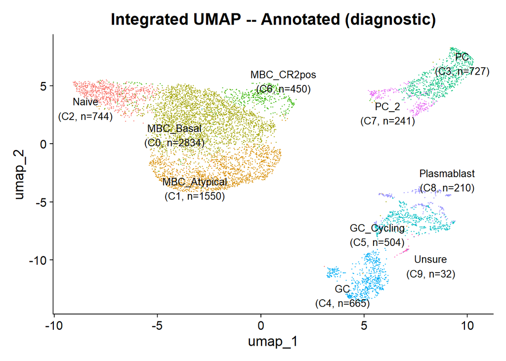

```r
annotation_summary$label <- paste0(
  annotation_summary$cell_type, "\n(C", annotation_summary$seurat_clusters,
  ", n=", annotation_summary$n_cells, ")"
)
label_map           <- setNames(annotation_summary$label,
                                as.character(annotation_summary$seurat_clusters))
obj$cell_type_label <- unname(label_map[as.character(obj$seurat_clusters)])

Idents(obj) <- "cell_type_label"
print(
  DimPlot(obj, reduction = "umap", label = TRUE, label.size = 3.5, repel = TRUE) +
    ggtitle("Integrated UMAP -- Annotated (diagnostic)") +
    theme(plot.title = element_text(hjust = 0.5), legend.text = element_text(size = 8)) +
    NoLegend()
)
```

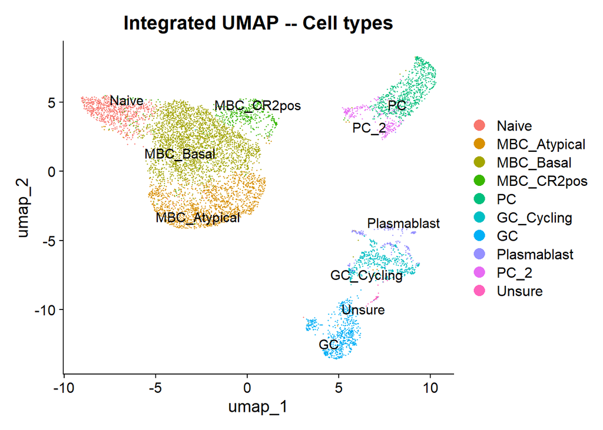

```r
Idents(obj) <- "cell_type"
print(
  DimPlot(obj, reduction = "umap", label = TRUE, label.size = 4, repel = TRUE) +
    ggtitle("Integrated UMAP -- Cell types") +
    theme(plot.title = element_text(hjust = 0.5)) +
    guides(color = guide_legend(override.aes = list(size = 4)))
)
```

```r
Idents(obj) <- "seurat_clusters"
```

## 7.18 Annotated DotPlot in canonical cluster order

With annotations assigned, we produce a final DotPlot using the cell type labels in the canonical cluster order. This mirrors the numbered DotPlot from section 7.4 but with interpretable names on the y-axis.

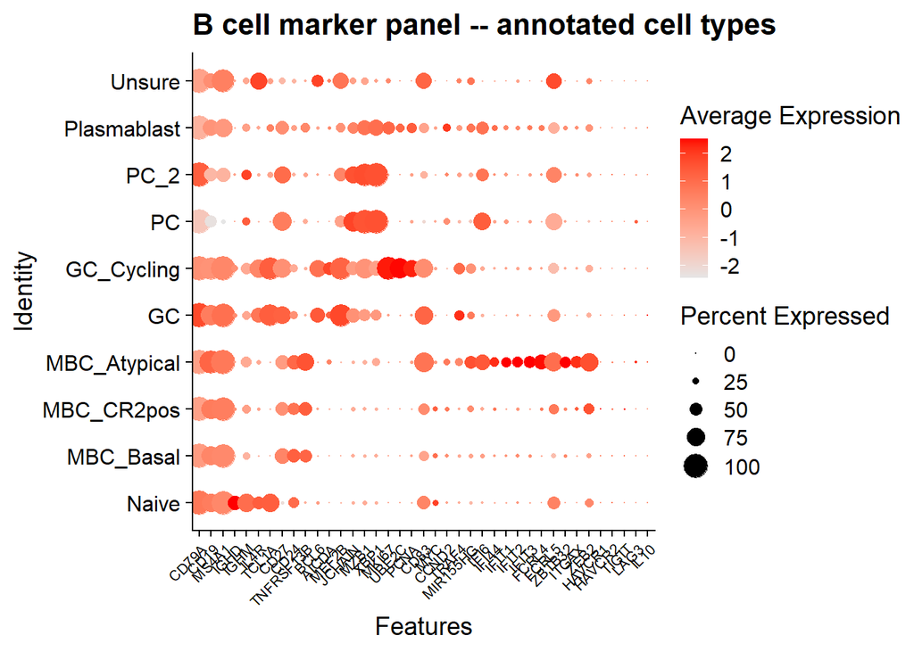

```r
cluster_order <- c(
  "Naive", "MBC_Basal", "MBC_CR2pos", "MBC_Atypical",
  "GC", "GC_Cycling", "PC", "PC_2", "Plasmablast", "Unsure"
)

Idents(obj) <- "cell_type"
obj$cell_type <- factor(obj$cell_type, levels = cluster_order)
Idents(obj)   <- "cell_type"

markers_present_annot <- intersect(b_cell_markers, rownames(obj))
print(
  DotPlot(obj, features = markers_present_annot,
          cols = c("gray90", "red"), dot.scale = 6) +
    RotatedAxis() +
    ggtitle("B cell marker panel -- annotated cell types") +
    theme(axis.text.x = element_text(size = 8))
)
```

```r
Idents(obj) <- "seurat_clusters"
```

## 7.19 Interpreting the annotations

The annotated UMAP shows the full B cell landscape across both tissues.

**GC and PC compartment (clusters 3, 4, 5, 7, 8):** The tumor site harbors an active germinal center response. GC shows the BCL6/MEF2B/SERPINA9 signature without proliferation. GC_Cycling carries the same GC program with an added mitotic signature and ~100% S+G2M phase composition. PC is the dominant antibody-secreting population, defined by heavy Ig V gene transcription and ER and secretory machinery (SSR4, PRDX4, ITM2C, SPAG4, FCGRT). PC_2 is a smaller, distinct PC subset with retained GC-leaning features (RGS13, RUNX1) and a broader transcription factor / scaffolding program rather than dominant secretory machinery. Plasmablast layers a pure cycling program (HIST1H3C, UBE2C, CCNA2, CDK1, MKI67, TOP2A, AURKB) on top of the PC markers, with ~100% S+G2M composition.

**Naive B cells (cluster 2):** TCL1A, IGHD, IGHM, IL4R, and CD200 with near-zero clonality and SHM, and an IgM/IgD-dominant isotype profile. LN-enriched, as expected.

**Cluster 9 (Unsure):** 32 cells with no interpretable B cell identity signature at this cell count. Likely the leading edge of a population that would resolve with more cells, rather than a distinct biological state.

# Save

```r
rds_out_s7 <- file.path(RDS_DIR, "integrated_S7_annotated.rds")
saveRDS(obj, file = rds_out_s7)
message("Saved: ", rds_out_s7)
```

```
## Saved: C:/Users/natha/OneDrive/Documents/Immcantation/BCR_Tutorial/Github/RDS_Objects/integrated_S7_annotated.rds
```

```r
message("Cell types: ", paste(sort(unique(obj$cell_type)), collapse = ", "))
```

```
## Cell types: Naive, MBC_Basal, MBC_CR2pos, MBC_Atypical, GC, GC_Cycling, PC, PC_2, Plasmablast, Unsure
```

```r
message("Cells: ", ncol(obj))
```

```
## Cells: 7957
```

*Part 2 complete. Annotated Seurat object saved to `RDS_Objects/`. Continue to Part 3 (BCR_GEX_Tutorial_Part3.Rmd) for BCR visualization and shared clone analysis.*